# Badanie ścieżek odwiedzających wystawę Regeneracja

Izabela Lis, Aleksandra Paluszyńska, Zofia Prucnal

13 kwietnia 2016

## Pytania badawcze: analiza ścieżek

#### Jakie ścieżki są typowe?

#### Które eksponaty były odwiedzane po których?

#### Które eksponaty były zwykle odwiedzane pierwsze, a które jako ostatnie?

#### Jakie podścieżki były często realizowane przez odwiedzających?

## Plan

Zajmiemy się ścieżkami odwiedzających wystawę Regeneracja w styczniu. Najpierw popatrzymy się na **statystyki przejść** od jednego eksponatu do drugiego (jakie były najczęstsze itp.), następnie przeanalizujemy **popularne podścieżki** czyli sekwencje kilku przejść między eksponatami aby wreszcie wykonać **klasteryzację odwiedzających** ze względu na ich ścieżki odwiedzin kolejno: wszystkich odwiedzających, a następnie tylko tych, którzy widzieli co najmniej dziesięć eksponatów.

W całej analizie będziemy zajmować się przejściami pomiędzy dwoma eksponatami oraz ich sekwencjami (podścieżkami, całymi ścieżkami), a więc na samym początku **usunęliśmy ze zbioru osoby, które obejrzały tylko jeden eksponat na wystawie** (nie zrobiły żadnego przejścia.)

## Pakiety

```r
setwd("~/UW/Statystyka_II/Projekt1")
library(ggplot2)
library(vegan) # pozwala na obliczanie macierzy odległości metodą Jaccarda
library(cluster)
library(MASS) # do rzutowania na dwa wymiary
```

## Import danych

W pierwszej fazie nie zidentyfikowałyśmy żadnych różnic pomiędzy zachowaniami odwiedzających wystawę Regeneracja w poszczególnych miesiącach. Dlatego uważamy za uzasadnione **ograniczenie obecnej analizy do stycznia** w celu ograniczenia rozmiaru macierzy odległości z 120 tysięcy x 120 tysięcy na około 20 tysięcy x 20 tysięcy, co jest na granicy wydolności naszych komputerów.

Wczytujemy teraz nasze dane w różnych postaciach, każda przyda się do czego innego.

### Macierz ze zmienną oznaczającą przejście visitorów od stacji do stacji

```r
data <- read.csv("faza2_data.csv")
data <- data[,-c(1,2)]
data$visitor <- as.factor(data$visitor)
data$visitor <- droplevels(data$visitor)
data$przejscie <- as.character(data$przejscie)
data$skad <- as.character(data$skad)
# Zobaczmy jak ona wygląda
head(data, n=10)
```

```
##    station visitor      przejscie   skad
## 1    cnk09  795453   cnk07->cnk09  cnk07
## 2    cnk16  795453   cnk09->cnk16  cnk09
## 3    cnk23  795453   cnk16->cnk23  cnk16
## 4    cnk61  795453   cnk23->cnk61  cnk23
## 5   cnk29a  795453  cnk61->cnk29a  cnk61
## 6    cnk69  795453  cnk29a->cnk69 cnk29a
## 7    cnk57  795453   cnk69->cnk57  cnk69
## 8    cnk24  795453   cnk57->cnk24  cnk57
## 9   cnk42a  795453  cnk24->cnk42a  cnk24
## 10  cnk29a  795455 cnk46a->cnk29a cnk46a
```

### Macierz ze ścieżkami visitorów w kolumnach

```r
przejscia <- read.csv("faza2_przejscia.csv", stringsAsFactors = FALSE)
przejscia <- przejscia[,-1]
# Zobaczmy jak ona wygląda
przejscia[1:10,1:5]
```

```
##          v795453        v795455        v795457       v795459       v795467
## 1   cnk07->cnk09 cnk46a->cnk29a cnk46b->cnk29a cnk29a->cnk75 cnk10->cnk63a
## 2   cnk09->cnk16  cnk29a->cnk66           <NA>          <NA>          <NA>
## 3   cnk16->cnk23   cnk66->cnk10           <NA>          <NA>          <NA>
## 4   cnk23->cnk61   cnk10->cnk21           <NA>          <NA>          <NA>
## 5  cnk61->cnk29a   cnk21->cnk69           <NA>          <NA>          <NA>
## 6  cnk29a->cnk69   cnk69->cnk72           <NA>          <NA>          <NA>
## 7   cnk69->cnk57           <NA>           <NA>          <NA>          <NA>
## 8   cnk57->cnk24           <NA>           <NA>          <NA>          <NA>
## 9  cnk24->cnk42a           <NA>           <NA>          <NA>          <NA>
## 10          <NA>           <NA>           <NA>          <NA>          <NA>
```

### Macierz ostatnich przejść visitorów

```r
ostatni <- read.csv("faza2_ostatni.csv")
ostatni$visitor <- unique(data$visitor)
ostatni <- ostatni[,-1]
# Zobaczmy jak ona wygląda
head(ostatni, n=5)
```

```
##                x visitor
## 1  cnk24->cnk42a  795453
## 2   cnk69->cnk72  795455
## 3 cnk46b->cnk29a  795457
## 4  cnk29a->cnk75  795459
## 5  cnk10->cnk63a  795467
```

### Macierz zero-jedynkowa (tracimy kolejność przejść!)

```r
dane <- read.csv("faza2_liczby_przejsc.csv")
rownames(dane) <- dane$X
dane <- dane[,-1]
# Zobaczmy jak ona wygląda
dane[1:10,1:7]
```

```
##                v795453 v795455 v795457 v795459 v795467 v795468 v795476
## cnk07->cnk09         1       0       0       0       0       0       0
## cnk09->cnk16         1       0       0       0       0       0       0
## cnk16->cnk23         1       0       0       0       0       0       0
## cnk23->cnk61         1       0       0       0       0       0       0
## cnk61->cnk29a        1       0       0       0       0       0       0
## cnk29a->cnk69        1       0       0       0       0       0       0
## cnk69->cnk57         1       0       0       0       0       0       0
## cnk57->cnk24         1       0       0       0       0       0       0
## cnk24->cnk42a        1       0       0       0       0       0       0
## cnk46a->cnk29a       0       1       0       0       0       0       0
```

```r
# Transponujemy, żeby skorzystać z funkcji vegdist
danet <- as.data.frame(t(dane))
```

## Statystyki przejść

### Liczby odwiedzonych eksponatów

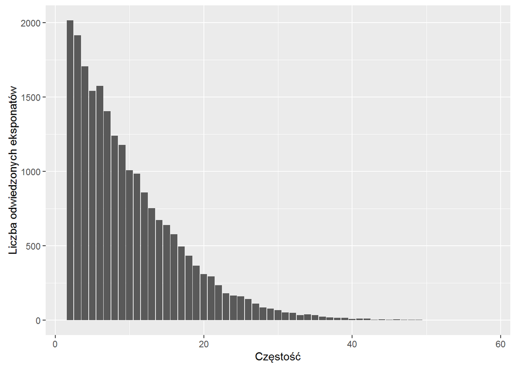

```r
# Ile przejść odwiedzający robili (liczba przejść = długość ścieżki-1)
dlugosc_sciezek <- as.data.frame(table(colSums(is.na(przejscia))))
dlugosc_sciezek$dlugosc <- 57 - as.numeric(as.character((dlugosc_sciezek$Var1))) + 1
ggplot(dlugosc_sciezek, aes(dlugosc, Freq))+ geom_bar(stat="identity") +
    scale_y_continuous(name="Liczba odwiedzonych eksponatów") +
    scale_x_continuous(name="Częstość")
```

### Popularność poszczególnych przejść

#### Przejścia ogółem

```r
temp1 <- as.data.frame(table(data$przejscie))
# Najczęstsze przejścia
tail(temp1[order(temp1$Freq),], n=10)
```

```
##                Var1 Freq
## 990    cnk20->cnk12  808
## 1048   cnk21->cnk12  840
## 51    cnk02a->cnk67  846
## 701    cnk16->cnk12  909
## 355    cnk09->cnk16  918
## 592    cnk12->cnk21  982
## 3263  cnk78a->cnk23  984
## 591    cnk12->cnk20 1101
## 863   cnk18->cnk78a 1526
## 880  cnk19a->cnk19b 1738
```

#### Ostatnie przejścia

```r
temp <- as.data.frame(table(ostatni$x))
# Najczęstsze ostatnie przejścia
tail(temp[order(temp$Freq),], n=10)
```

```
##                Var1 Freq
## 1931  cnk48a->cnk37   70
## 1748   cnk45->cnk75   78
## 1834  cnk46b->cnk47   79
## 2472 cnk63a->cnk100   83
## 1372   cnk37->cnk38   85
## 1120  cnk25->cnk29a   93
## 1951 cnk48a->cnk63a   96
## 959   cnk22->cnk29a  111
## 1393  cnk37->cnk63a  121
## 752  cnk19a->cnk19b  274
```

#### Które stacje były najczęściej odwiedzane jako pierwsze?

```r
pierwsze <- as.data.frame(t(przejscia[1,]))
pierwsze$visitor <- colnames(przejscia)
pierwsze$skad <- sub("->.*", "", pierwsze[,1])
temp3 <- as.data.frame(table(pierwsze$skad))
tail(temp3[order(temp3$Freq),], n=10)
```

```
##      Var1 Freq
## 14  cnk17  674
## 16 cnk19a  699
## 6   cnk07  707
## 13  cnk16  713
## 9  cnk100  747
## 4   cnk05  956
## 8   cnk10  958
## 52  cnk67 1055
## 2  cnk02b 3413
## 1  cnk02a 3766
```

#### Które stacje były najczęściej odwiedzane jako ostatnie?

```r
ostatni$dokad <- sub(".*->", "", ostatni$x)
temp2 <- as.data.frame(table(ostatni$dokad))
tail(temp2[order(temp2$Freq),], n=10)
```

```
##      Var1 Freq
## 31  cnk40  514
## 38  cnk47  556
## 57  cnk75  599
## 28  cnk37  612
## 39 cnk48a  646
## 25 cnk29a  698
## 43  cnk56  701
## 9  cnk100  715
## 32 cnk42a  725
## 50 cnk63a 1074
```

## Analiza podścieżek

Patrząc na najczęstsze przejścia pomiędzy dwoma eksponatami wybieraliśmy podzbiory odwiedzających, którzy wykonywali to przejście i sprawdzałyśmy gdzie byli wcześniej i później, czyli przyglądałyśmy się najpopularniejszym podścieżkom o długości większej niż dwa eksponaty. Wyniki naszej analizy można przedstawić na mapce wystawy:

### Podścieżki i najczęstsze wejścia/wyjścia: cała mapka

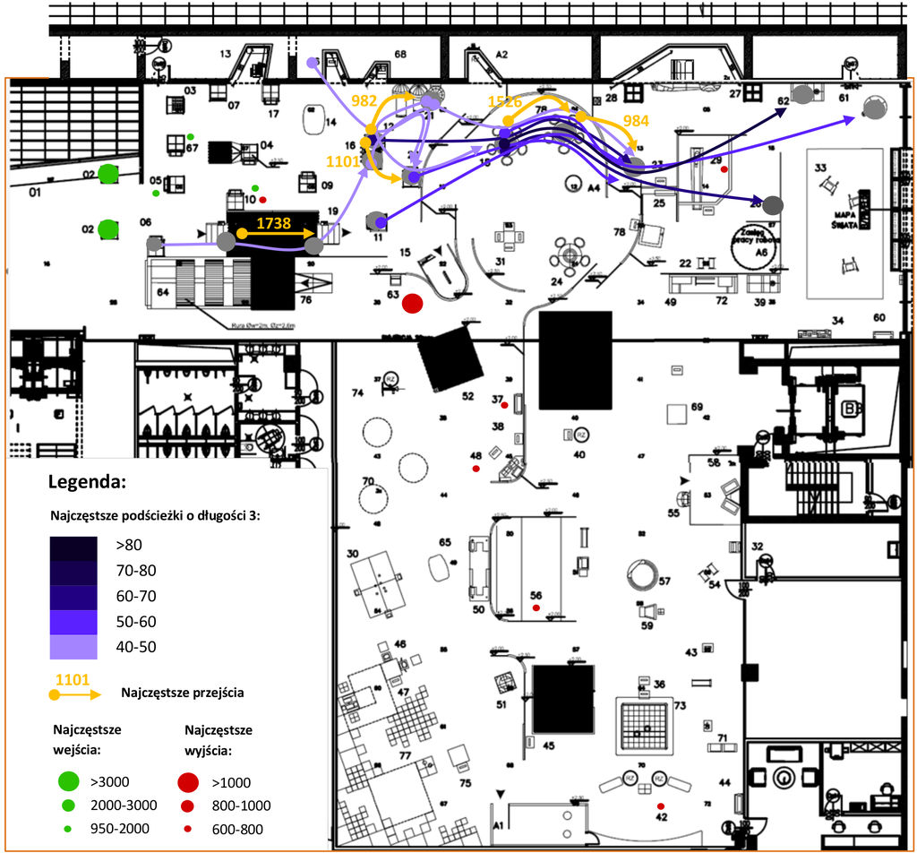

**Komentarz:** Zauważmy, że najczęstsze wejścia i wyjścia to w przypadku wejść zdecydowanie dominują 2a i 2b (ok 3500) później długo nic i kolejna trójka najczęstszych wejść ma już częstotliwości w okolicach 1000. (->na wykresie ie ma średnich kropek, są tylko duże albo małe) To samo w przypadku wyjść, jest jedno dominujące (duża kropka), później długo nic i kolejne są już kwalifikowane jak zdecydowanie mniej znaczące (też nie ma średnich kropek).

### Podścieżki i najczęstsze wejścia/wyjścia: fragment

[figure not shown]

**Komentarz:** Zwróćmy uwagę, że najbardziej popularne przejście (1738) nie wiąże się wcale z wieloma popularnymi podścieżkami (w przeciwieństwie do drugiego najbardziej popularnego co ma 1526). Wynika to z tego, że interacja z maszyną cnk19a (sala strachów wejście) wymuszała interakcję z maszyną cnk19b (sala strachów wyjście).

## Analiza podobieństwa odwiedzających

Spróbujmy znaleźć grupy podobnych visitorów (a zarazem ich ścieżek). Mamy nadzieję, że to pozwoli nam zidentyfikować jakieś wzorce.

### Macierz odległości

Najpierw wyznaczamy macierz odległości metodą Jaccarda, która liczy frakcję jedynek (fakt wystąpienia przejścia) występującą na tych samych miejscach u obu odwiedziających spośród maksymalnej liczby jedynek (przejść) obu porównywanych odwiedzających. Tym samym odległość między odwiedzającymi będzie 0 jeśli obaj zaliczyli te same przejścia między eksponatami (niekoniecznie w tej samej kolejności).

```r
distance <- vegdist(danet, method="jaccard")
```

### Klasteryzacja hierarchiczna

Następnie wykonamy klasteryzację. Ze względu na rozmiar dendrogramów wczytamy tylko ich ciekawe fragmenty z pliku.

#### Metoda “single”

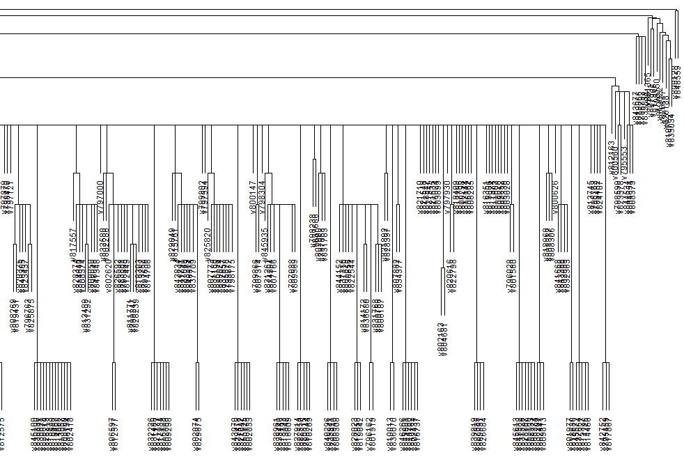

```r
cluster1 <- hclust(distance, method = "single")
plot(cluster1)
```

**Komentarz:** podział drzewa zaczyna się z lewej, gdzie pięciu odwiedzających nie łączy się z żadnymi grupami, następnie jest kilka zagnieżdżonych podziałów na dwa klastry: jeden jednoelementowy i drugi długi, podział ten ciągnie się (z nielicznymy “wystającymi” parami) aż do końca, przedstawionego na rysunku. Na nim widzimy podział na kilka większych klastrów o diametralnie różnych rozmiarach (dolny - wielki i malutkie na górze).

#### Metoda “average”

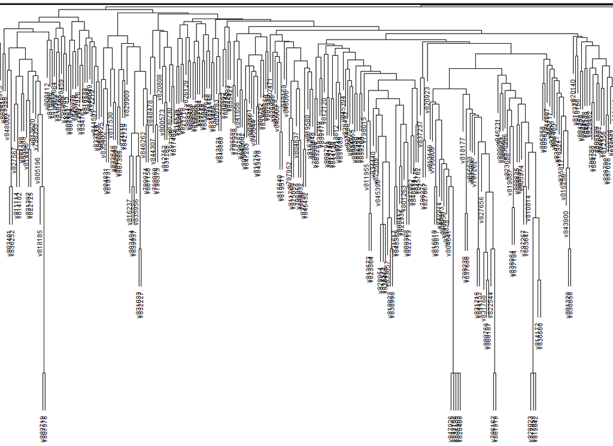

```r
cluster3 <- hclust(distance, method = "average")
plot(cluster3)
```

**Komentarz:** cały dendrogram wygląda podobnie: podział na górze jest bardzo gęsty (20 tysięcy obserwacji daje kilkadziesiąt klastrów przy przycięciu na samej górze), potem widać wiele rozgałęzień aż do par odwiedzających.

#### Metoda “complete”

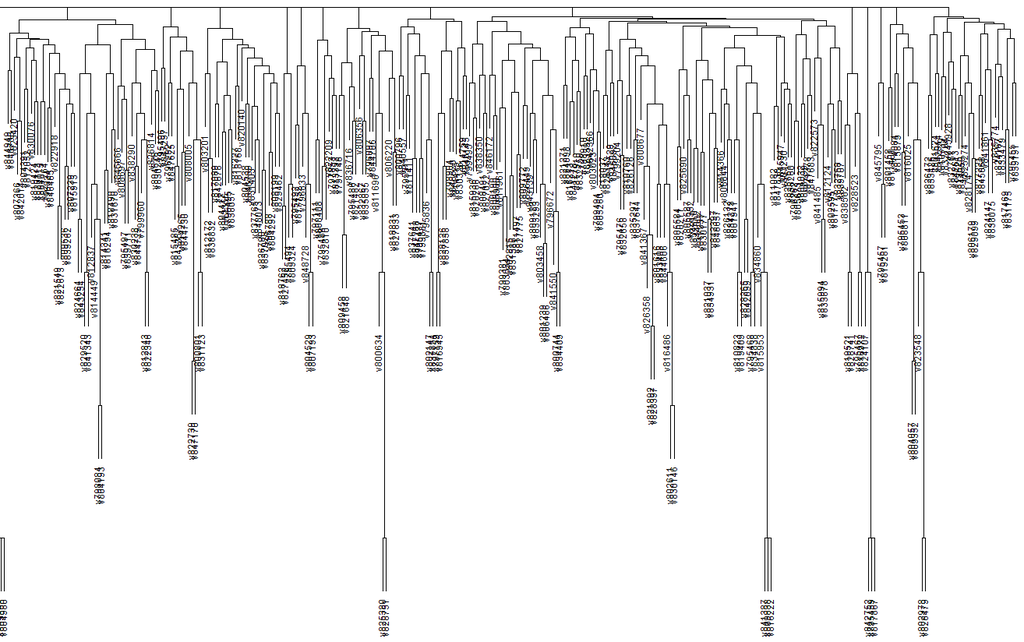

```r
cluster2 <- hclust(distance, method = "complete")
plot(cluster2)
```

**Komentarz:** cały dendrogram wygląda podobnie jak ten dla metody “average”, z tą różnicą, że podział jest znacznie gęstszy i dowolny punkt odcięcia da podział na setki klastrów, widać to również na przykładowym kawałku z końca drzewa (rysunek)

#### Metoda “ward.D2”

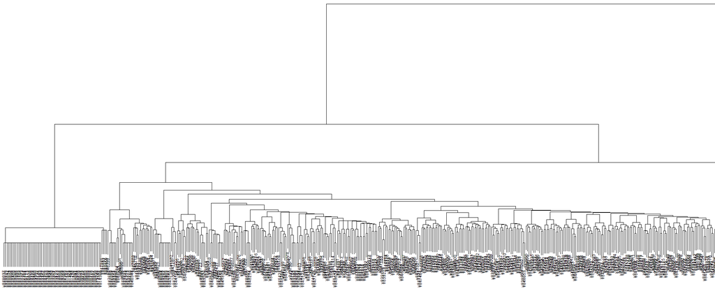

```r
cluster4 <- hclust(distance, method = "ward.D2")
plot(cluster4)
```

**Komentarz:** na całym dendrogramie wyraźnie widać podział na dwa klastry z których jeden jest mniejszy (na rysunku), a drugi olbrzymi. W zależności od punktu odcięcia można otrzymać różne “sensowne” liczby klastrów, co było niemożliwe po zastosowaniu poprzednich metod.

#### Wnioski

- Tylko metoda Warda pozwoliła na sensowny podział odwiedzających na klastry, pozostałe metody wyróżniły pewne podgrupy tylko na dole drzewa co uniemożliwia sensowne przycięcie drzewa.
- Wszystkie metody wyróżnieją **pary odwiedzających** lub większe ich grupki, co można wyjaśnić chodzeniem odwiedzających razem po wystawie.

## Analiza podobieństwa podgrupy odwiedzających

Teraz patrzymy tylko na tych, którzy przeszli co najmniej 10-elementową ścieżkę

### Przeróbmy dane

```r
dlugie <- as.data.frame(t(przejscia[-(1:9),]))
dlugie$brak <- (rowSums(is.na(dlugie)) == 48)
wybrani <- rownames(subset(dlugie, brak == FALSE))
wybor <- as.data.frame(rownames(danet) %in% wybrani)
danedl <- danet[wybor==TRUE,]
przejsciadl <- przejscia[,(colnames(przejscia) %in% wybrani)]
```

### Macierz odległości

```r
distancedl <- vegdist(danedl, method="jaccard")
```

### Rzutowanie na przestrzeń dwuwymiarową

Przy zmniejszonym wymiarze zadania możemy zobaczyć jak wyglądają odległości pomiędzy odwiedzającymi po rzutowaniu ich na dwa wymiary, wykorzystamy do tego funkcję `cmdscale()` oraz `isoMDS()` (ta druga nie toleruje zerowych odległości między jednostkami, które u nas występują, więc musimy dodać epsilon do naszej macierzy odległości).

#### Metoda CMD

[figure not shown]

```r
trans1 <- as.data.frame(cmdscale(distancedl, k=2))
plot(Shepard(distancedl, as.matrix(trans1)), pch=20)
```

#### Metoda ISO

[figure not shown]

```r
distancedl_eps <- distancedl + 0.001
trans2 <- as.data.frame(isoMDS(distancedl_eps, k=2)[["points"]])
plot(Shepard(distancedl, as.matrix(trans2)), pch=20)
```

### Klasteryzacja hierarchiczna

Tym razem skupimy się na klasteryzacji metodą Warda, która dała obiecujące wyniki dla całego zbioru.

#### Cały dendrogram

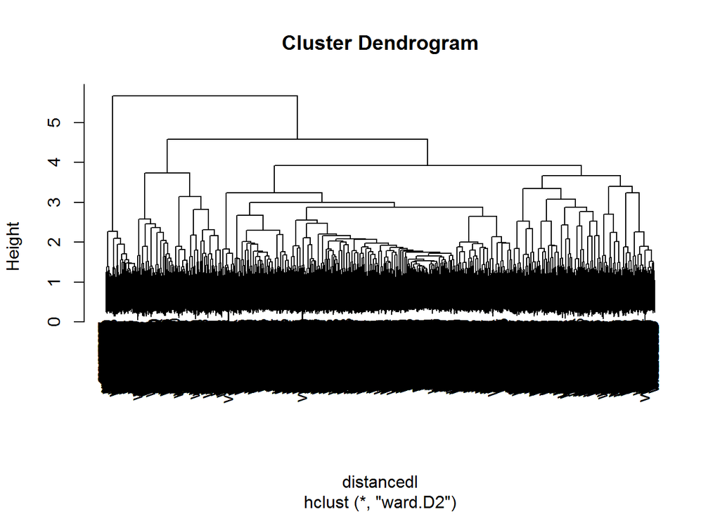

```r
load("Faza2_distance_dlugie.rda")
load("Faza2_rzut_cmd_dlugie.rda") # wczytujemy współrzędne z rzutu CMD
load("Faza2_rzut_iso_dlugie.rda") # wczytujemy współrzędne z rzutu ISO
cluster5 <- hclust(distancedl, method = "ward.D2")
plot(cluster5)
```

#### Przycinamy drzewo

```r
klastry <- cutree(cluster5, k = 4)
table(klastry)
```

```
## klastry
##    1    2    3    4
## 2052 4215 1241  439
```

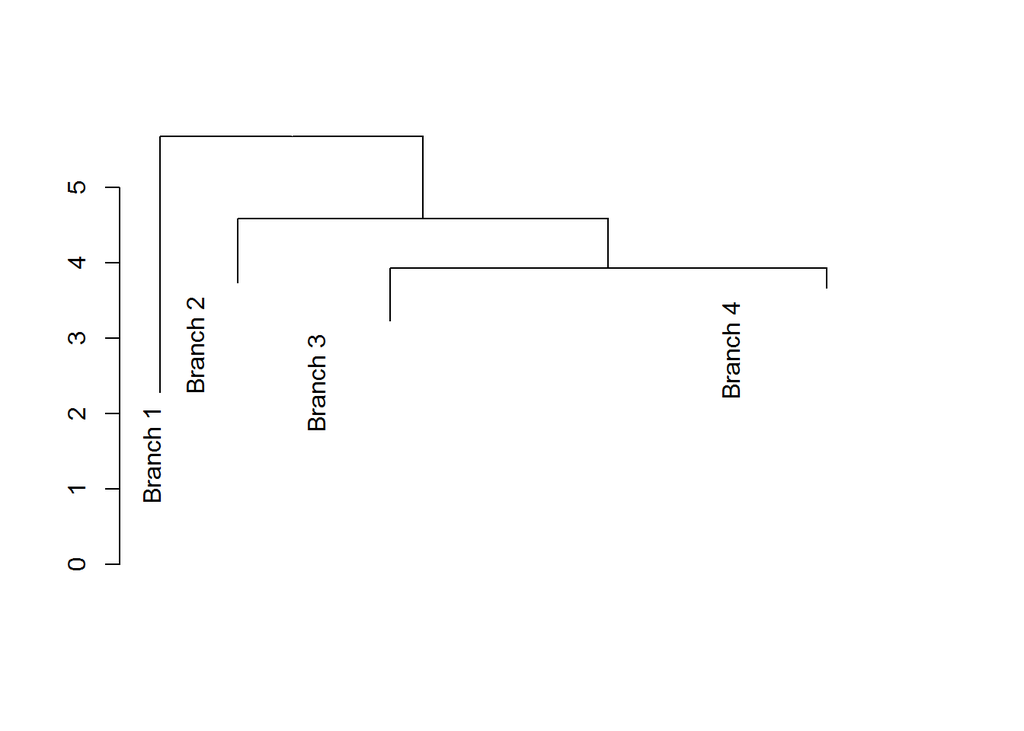

```r
plot(cut(as.dendrogram(cluster5), h = 3.8)$upper)
```

```r
klastry10 <- cutree(cluster5, k = 10)
table(klastry10)
```

```
## klastry10
##    1    2    3    4    5    6    7    8    9   10
##  292 4031  147  945  683  343  325  558  184  439
```

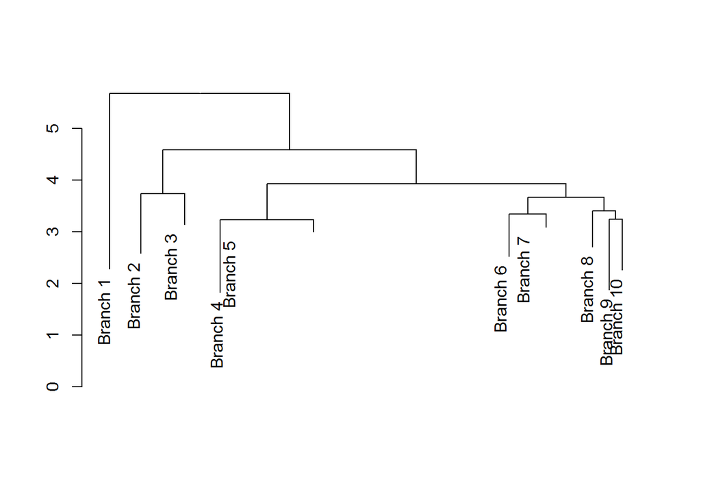

```r
plot(cut(as.dendrogram(cluster5), h = 3.2)$upper)
```

#### Cztery klastry a rzutowanie CMD

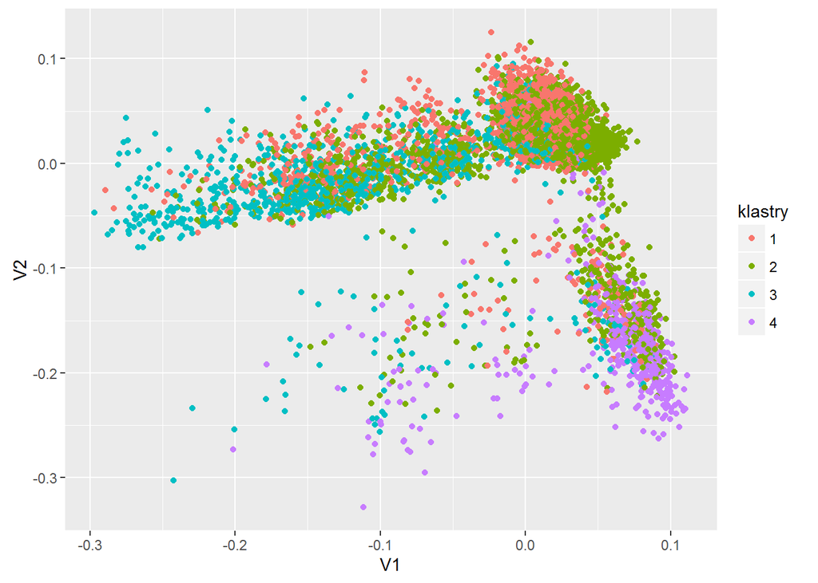

```r
trans1$klastry <- as.factor(klastry)
ggplot(trans1, aes(V1, V2, color=klastry)) + geom_point()
```

#### Cztery klastry a rzutowanie ISO

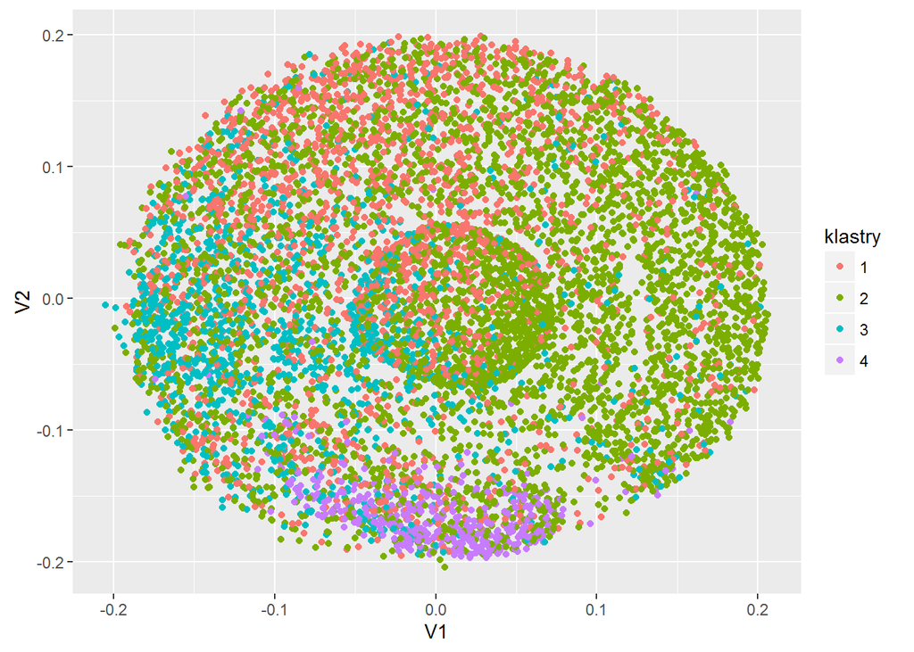

```r
trans2$klastry <- as.factor(klastry)
ggplot(trans2, aes(V1, V2, color=klastry)) + geom_point()
```

#### Dziesięć klastrów a rzutowanie CMD

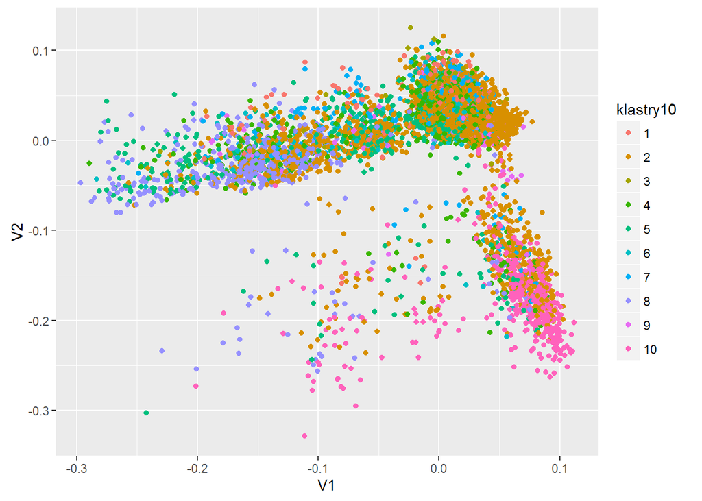

```r
trans1$klastry10 <- as.factor(klastry10)
ggplot(trans1, aes(V1, V2, color=klastry10)) + geom_point()
```

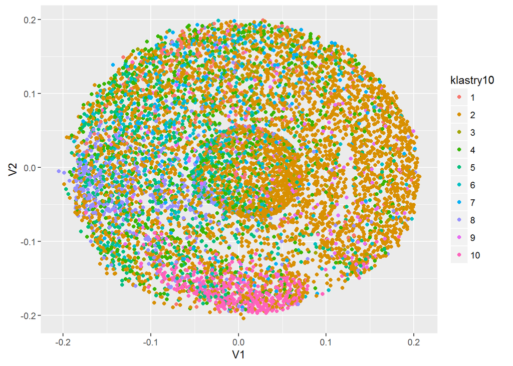

```r
trans2$klastry10 <- as.factor(klastry10)
ggplot(trans2, aes(V1, V2, color=klastry10)) + geom_point()
```

#### Wnioski

- rzutowanie ISO nie jest w naszej sytuacji najlepsze: klastry się zupełnie mieszają,
- rzutowanie CMD jest trochę lepsze dla czterech klastrów, ale dla dziesięciu już nie,
- wyraźnie widoczne klastry w rzutowaniu CMD nie są wychwytywane przez klasteryzację w oryginalnym wymiarze.

### Klasteryzacja k-medoidów dla k=4

```r
grupy <- pam(distancedl, k=4)
# grupy$medoids
klastry2 <- grupy$clustering
table(klastry2)
```

```
## klastry2
##    1    2    3    4
## 1686 3114 1251 1896
```

#### Podział na klastry w rzutowaniu CMD

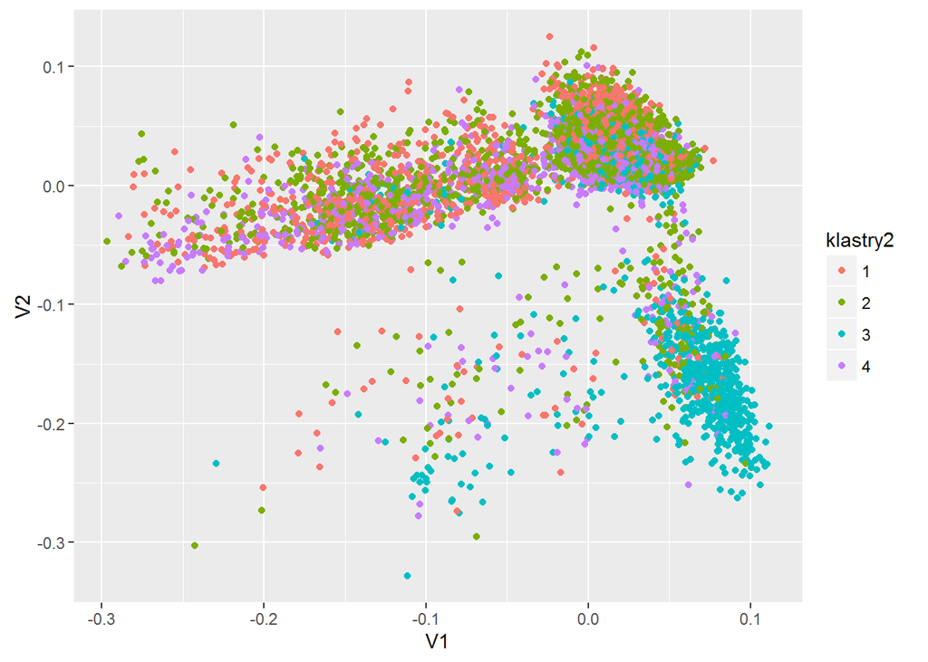

```r
trans1$klastry2 <- as.factor(klastry2)
ggplot(trans1, aes(V1, V2, color=klastry2)) + geom_point()
```

#### Medoidy na mapce

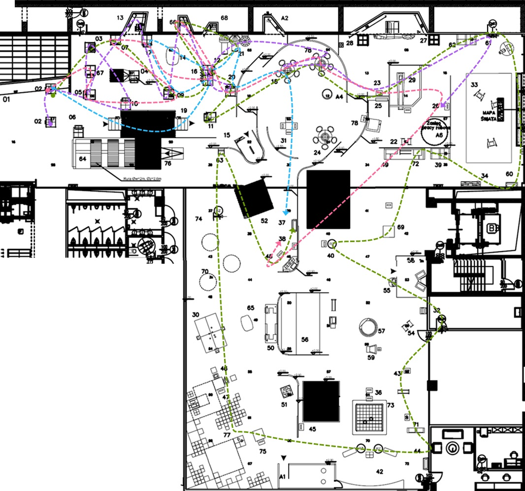

#### Wnioski

- **Jest pewna grupa osób, które chodzą “porządnie” po tej galerii**, czyli od początku do końca, obchodząc najbardziej interesujące eksponaty galerii i chodząc po wszytkich zakamarkach (szczególnie tam na dole mapy) i to reprezentuje medoid zielony.
- Ciekawa jest **grupa reprezentowana przez medoid fioletowy**, bo jego ścieżka jest bardzo nieuporządkowana. Nie dość, że na początku się kręci trochę w kółko po tych pierwszych stacjach, robiąc pętelki, to co jest bardzo ciekawe powtarza jeden eksponat: 78->18->78.
- Te dwa medoidy są najbardziej różne, natomiast niebieski i różowy są bardziej uśrednione i obrazują ścieżki które ani nie są przesadnie uporządkowane i dokładne, ani przesadnie zabałaganione. I one reprezentują największą część ścieżek.